# My Music Listening Habits

## What is my data telling us?

My data analyses my music listening habits every time I listened to music. Every time I started playing music until I stopped playing music was called a session, so on some days I had multiple listening sessions.

## Why? and for how long?

One of the first things I wanted to look at was what sorts of activities provoked me to start listening to music. I wanted to compare this to how long these listening sessions tended to last.

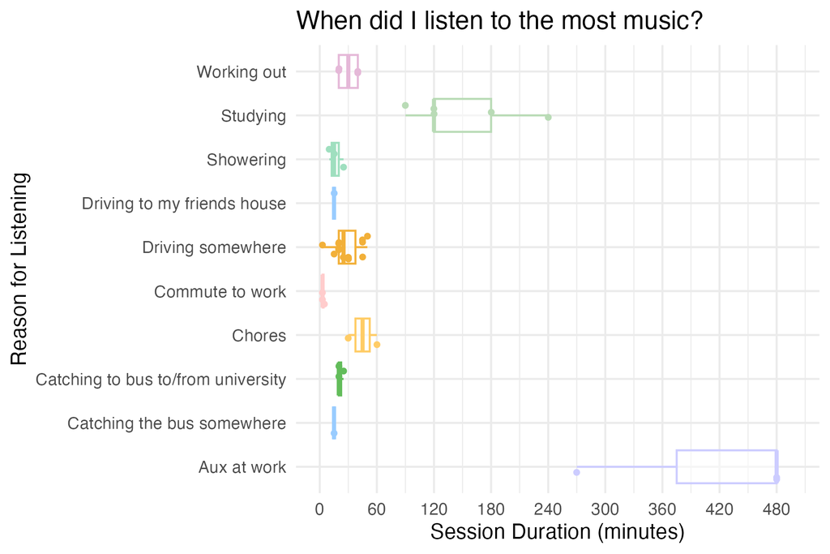

The data is clearly right skewed. Most listening sessions tended to be under an hour for the majority of tasks. The longest listening sessions also had the largest range of listening durations. When I was on the AUX at work or studying, I tended to listen in one consecutive session for much longer and varied time periods. One of the most common reasons I listened to music was when I driving somewhere, which has many data points. There was a wide range of duration when driving compared to the other listening reasons on this side of the graph as I have a mix of short and long drives that I routinely take throughout the week.

## But where was I having the most fun?

I wanted to use these reasons to compare how much I enjoyed listening to music in each session, to find out if the reason for listening influenced my perception.

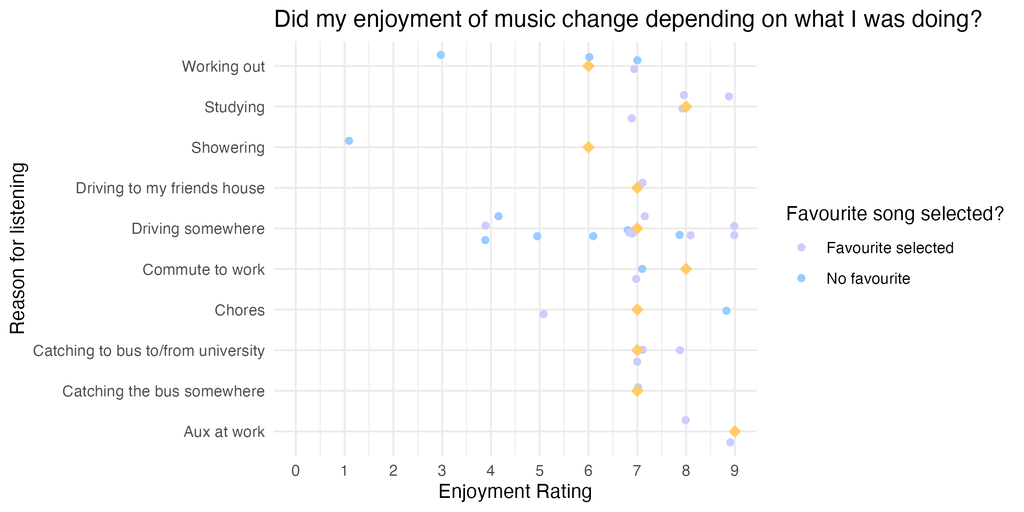

This plot shows the reason for listening against the enjoyment rating for the session. The orange diamonds depind the mean rating for that listening reason. Higher numbers depict a more positive listening experience while lower rating depicted a negative listening experience. The data shows that on average, I enjoyed most music no mater what I was doing. However, the highest enjoyment ratings came from listening at work and studying. From our previous plot, we know that this is when I tended to listen to music for the longest time and likely had more time to listen to a variety of songs. This may have increased my rating. My lowest ratings appeared to be from working out and showering. It is possible that during working out I was struggling and therefore was not enjoying my music as much. There are very few data points for showering and it likely that the rating of 1 was an outlier for a day that I didn’t enjoy what played at all.

## Where do I find my music?

The following plot depicts the source of the music based on the day of the week, and how often I listened to music on different days.

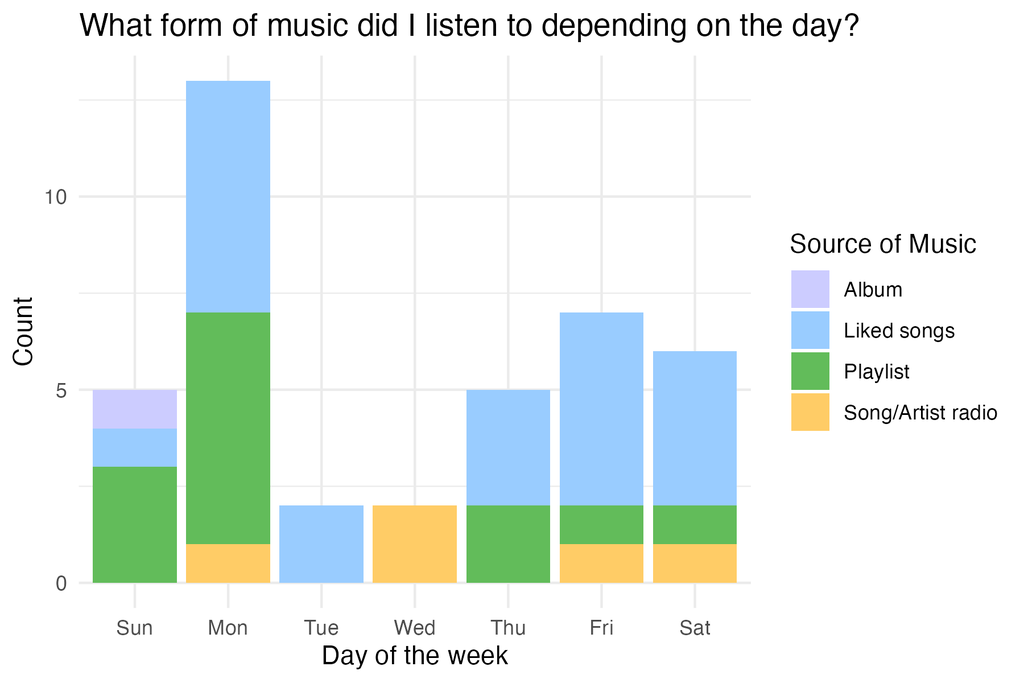

The plot shows that I listened to the most music on mondays and fridays. This makes sense as I don’t have work on mondays or fridays and tend to do a number of different tasks on these days. It makes sense that I would start multiple listening sessions on these days. It is clear that I tend to listen to music from my ‘Liked Songs’ the most and on Mondays I had more of a split between liked songs and playlists. This may be because when doing different tasks I may want a specific playlist eg working out or studying. Interestingly, on wednesdays I only listened to song radios. This makes sense because on Wednesdays I tend to be on AUX at work and often play a spotify radios to keep the music generic and appeal to everyone.

## Do specific songs effect my enjoyment?

Throughout my data collection, I selected whether a specific song stood out to me as a favourite of the listening session. I was intrested to know whether having a favourite song tended to influence my enjoyment of the session.

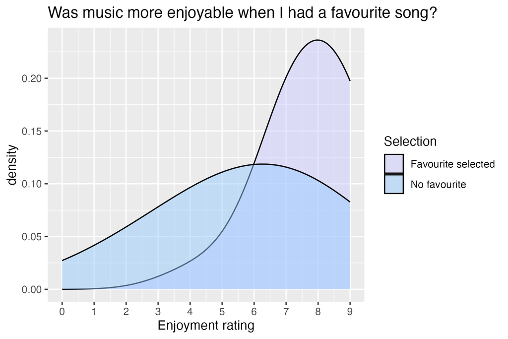

This plot shows the distribution of my ratings based on whether I selected a favourite song. It is clear that while I tended to rate my sessions highly regardless, I more frequently had a higher enjoyment rating when I had as favourite song. This may mean that a specific song could have made me enjoy my listening experience more.

## Why was a song my favourite?

There were a variety of reasons why a song was selected as my favourite.

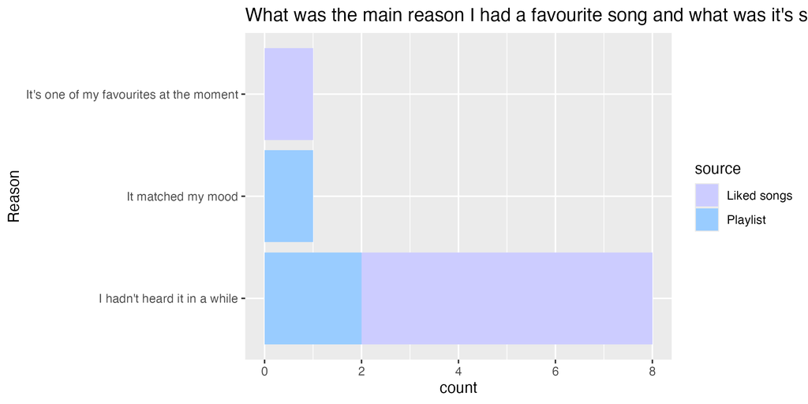

The large majority of favourite songs were selected because I hadn’t heard them in a while. This shows I that I may have been bored of hearing the same songs in my playlists and really enjoyed the experience of listening to a song that may be nostalgic. This plot shows that when listening to music from liked songs, I was able to hear songs I had not heard in a while. This makes sense as I have around 3000 songs in my liked songs meaning that there is a vast range that I may not get to listen too often.

## Am I repetitive?

As well as capturing whether i had a favourite song during a session, I also recorded whether I started a listening session by shuffling, or selected a specific song. When I selected a song, I also recorded why I selected that song to begin the session.

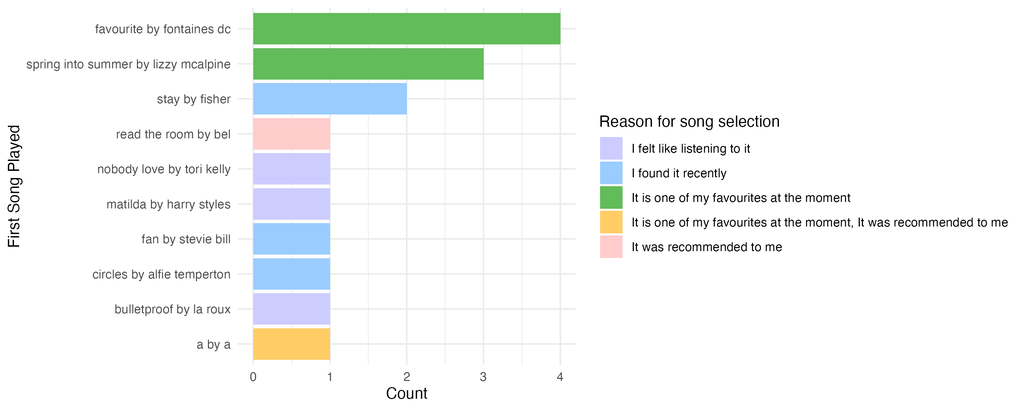

This plot shows that songs such as ‘Favourite’ and ‘Spring into summer’ were selected multiple times as the first song I wanted to listen to. Every time I chose these two songs it was because it was one of my favourite songs at the moment! No wonder I get sick of music and enjoy songs when I haven’t heard them in a while. It appears that I also tend to select songs to start my sessions because I found a song recently and want to hear it again. Random songs also appear once because on that day I felt like hearing them.

## What does this say about me?

It is very interesting to get data not only about what I listen to, but how, why and, whether I enjoyed listening to the music. It is clear I am a creature of habit and tend to do the same things frequently with not too much variation.